# INFSCI 2595: Spring 2020

Applied Machine Learning: Binary Classification

Dr. Joseph P. Yurko

## Overview

We will try out an applied machine learning binary classification demo using the Johns Hopkins Ionosphere data set. This data set is available from the https://archive.ics.uci.edu/ml/datasets/Ionosphere. It is also available directly in `R` via the `mlbench` package.

```r
library(dplyr)
```

```r
library(ggplot2)
library(caret)
```

## Data

Load in the `Ionosphere` data set from the `mlbench` package and check the dimensions.

```r
data("Ionosphere", package = "mlbench")

Ionosphere %>% dim()
```

```
## [1] 351  35
```

Print out the variable names.

```r
Ionosphere %>% names()
```

```
##  [1] "V1"    "V2"    "V3"    "V4"    "V5"    "V6"    "V7"    "V8"
##  [9] "V9"    "V10"   "V11"   "V12"   "V13"   "V14"   "V15"   "V16"
## [17] "V17"   "V18"   "V19"   "V20"   "V21"   "V22"   "V23"   "V24"
## [25] "V25"   "V26"   "V27"   "V28"   "V29"   "V30"   "V31"   "V32"
## [33] "V33"   "V34"   "Class"
```

Look at a summary of each variable.

```r
Ionosphere %>% summary()
```

```
##  V1      V2            V3                V4                 V5
##  0: 38   0:351   Min.   :-1.0000   Min.   :-1.00000   Min.   :-1.0000
##  1:313           1st Qu.: 0.4721   1st Qu.:-0.06474   1st Qu.: 0.4127
##                  Median : 0.8711   Median : 0.01631   Median : 0.8092
##                  Mean   : 0.6413   Mean   : 0.04437   Mean   : 0.6011
##                  3rd Qu.: 1.0000   3rd Qu.: 0.19418   3rd Qu.: 1.0000
##                  Max.   : 1.0000   Max.   : 1.00000   Max.   : 1.0000
##        V6                V7                V8                 V9
##  Min.   :-1.0000   Min.   :-1.0000   Min.   :-1.00000   Min.   :-1.00000
##  1st Qu.:-0.0248   1st Qu.: 0.2113   1st Qu.:-0.05484   1st Qu.: 0.08711
##  Median : 0.0228   Median : 0.7287   Median : 0.01471   Median : 0.68421
##  Mean   : 0.1159   Mean   : 0.5501   Mean   : 0.11936   Mean   : 0.51185
##  3rd Qu.: 0.3347   3rd Qu.: 0.9692   3rd Qu.: 0.44567   3rd Qu.: 0.95324
##  Max.   : 1.0000   Max.   : 1.0000   Max.   : 1.00000   Max.   : 1.00000
##       V10                V11                V12
##  Min.   :-1.00000   Min.   :-1.00000   Min.   :-1.00000
##  1st Qu.:-0.04807   1st Qu.: 0.02112   1st Qu.:-0.06527
##  Median : 0.01829   Median : 0.66798   Median : 0.02825
##  Mean   : 0.18135   Mean   : 0.47618   Mean   : 0.15504
##  3rd Qu.: 0.53419   3rd Qu.: 0.95790   3rd Qu.: 0.48237
##  Max.   : 1.00000   Max.   : 1.00000   Max.   : 1.00000
##       V13               V14                V15               V16
##  Min.   :-1.0000   Min.   :-1.00000   Min.   :-1.0000   Min.   :-1.00000
##  1st Qu.: 0.0000   1st Qu.:-0.07372   1st Qu.: 0.0000   1st Qu.:-0.08170
##  Median : 0.6441   Median : 0.03027   Median : 0.6019   Median : 0.00000
##  Mean   : 0.4008   Mean   : 0.09341   Mean   : 0.3442   Mean   : 0.07113
##  3rd Qu.: 0.9555   3rd Qu.: 0.37486   3rd Qu.: 0.9193   3rd Qu.: 0.30897
##  Max.   : 1.0000   Max.   : 1.00000   Max.   : 1.0000   Max.   : 1.00000
##       V17               V18                 V19
##  Min.   :-1.0000   Min.   :-1.000000   Min.   :-1.0000
##  1st Qu.: 0.0000   1st Qu.:-0.225690   1st Qu.: 0.0000
##  Median : 0.5909   Median : 0.000000   Median : 0.5762
##  Mean   : 0.3819   Mean   :-0.003617   Mean   : 0.3594
##  3rd Qu.: 0.9357   3rd Qu.: 0.195285   3rd Qu.: 0.8993
##  Max.   : 1.0000   Max.   : 1.000000   Max.   : 1.0000
##       V20                V21               V22
##  Min.   :-1.00000   Min.   :-1.0000   Min.   :-1.000000
##  1st Qu.:-0.23467   1st Qu.: 0.0000   1st Qu.:-0.243870
##  Median : 0.00000   Median : 0.4991   Median : 0.000000
##  Mean   :-0.02402   Mean   : 0.3367   Mean   : 0.008296
```

[output cut: 15 more lines]

```
##  Max.   : 1.0000   Max.   : 1.00000   Max.   : 1.0000   Max.   : 1.00000
##       V31               V32                 V33
##  Min.   :-1.0000   Min.   :-1.000000   Min.   :-1.0000
##  1st Qu.: 0.0000   1st Qu.:-0.242595   1st Qu.: 0.0000
##  Median : 0.4428   Median : 0.000000   Median : 0.4096
##  Mean   : 0.3525   Mean   :-0.003794   Mean   : 0.3494
##  3rd Qu.: 0.8576   3rd Qu.: 0.200120   3rd Qu.: 0.8138
##  Max.   : 1.0000   Max.   : 1.000000   Max.   : 1.0000
##       V34            Class
##  Min.   :-1.00000   bad :126
##  1st Qu.:-0.16535   good:225
##  Median : 0.00000
##  Mean   : 0.01448
##  3rd Qu.: 0.17166
##  Max.   : 1.00000
```

Check for variables with near-zero variance.

```r
nearZeroVar(Ionosphere)
```

```
## [1] 2
```

The second column in the data set, `V2`, is a constant value. We will remove it for modeling.

```r
my_ion <- Ionosphere %>% select(-V2)
```

Look at the counts of `V1`.

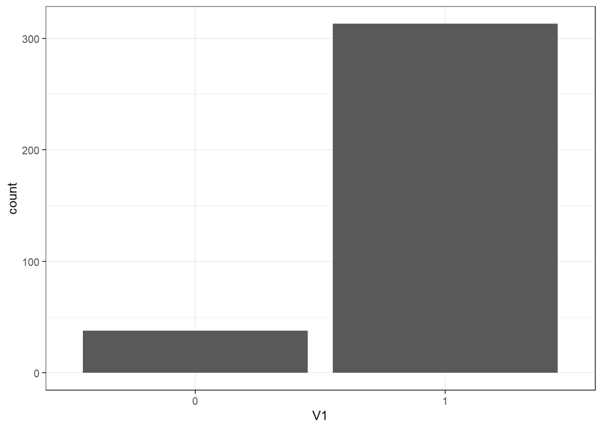

```r
my_ion %>%
  ggplot(mapping = aes(x = V1)) +
  geom_bar(mapping = aes(group = V1)) +
  theme_bw()
```

Break up by the output class of interest.

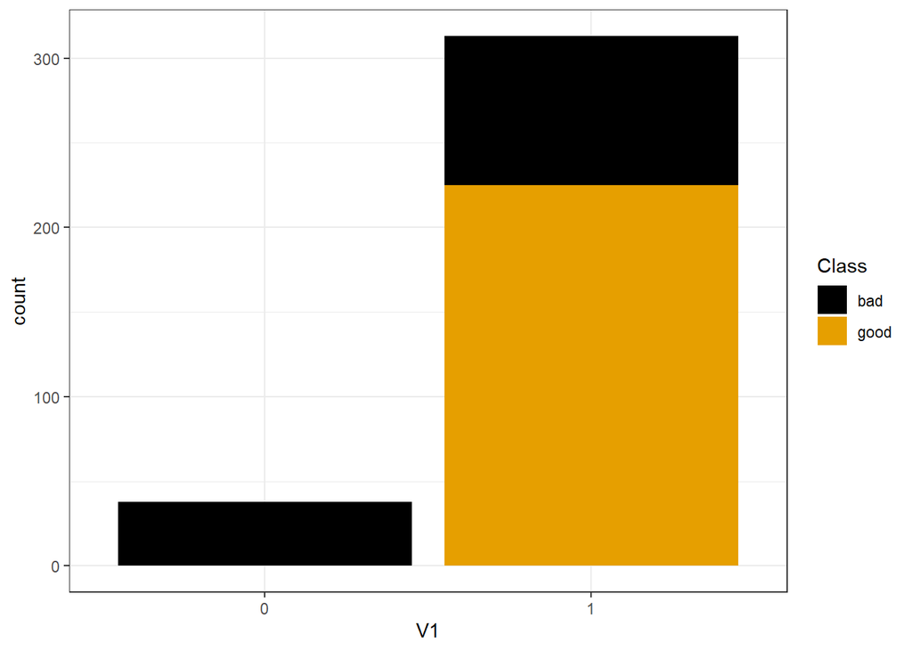

```r
my_ion %>%
  ggplot(mapping = aes(x = V1)) +
  geom_bar(mapping = aes(group = interaction(V1, Class),
                         fill = Class)) +
  ggthemes::scale_fill_colorblind() +
  theme_bw()
```

Start out removing `V1` as well since all of the `"good"` observations for `Class` correspond to that one level of the response of interest.

```r
my_ion <- my_ion %>%
  select(-V1) %>%
  mutate(Class = factor(Class, levels = c("good", "bad")))
```

Look at the counts of the output class.

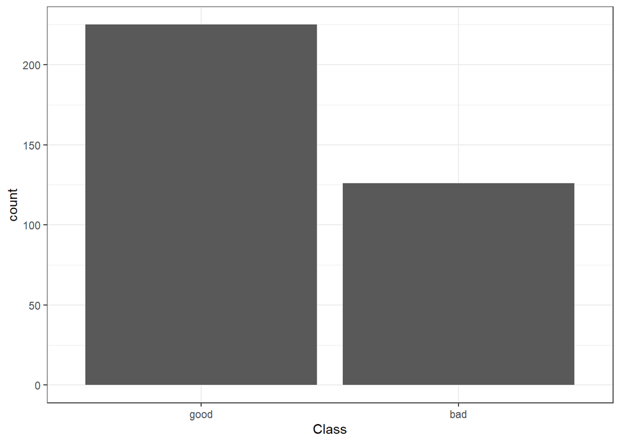

```r
my_ion %>%
  ggplot(mapping = aes(x = Class)) +
  geom_bar() +
  theme_bw()
```

Check if any values are missing from the inputs.

```r
my_ion %>%
  tibble::rowid_to_column("obs_id") %>%
  tidyr::gather(key = "key", value = "value", -obs_id, -Class) %>%
  group_by(key) %>%
  summarise(num_rows = n(),
            num_missing = sum(is.na(value)),
            num_unique = n_distinct(value)) %>%
  knitr::kable()
```

| key | num_rows | num_missing | num_unique |
| --- | --- | --- | --- |
| V10 | 351 | 0 | 267 |
| V11 | 351 | 0 | 246 |
| V12 | 351 | 0 | 269 |
| V13 | 351 | 0 | 238 |
| V14 | 351 | 0 | 266 |
| V15 | 351 | 0 | 234 |
| V16 | 351 | 0 | 270 |
| V17 | 351 | 0 | 254 |
| V18 | 351 | 0 | 280 |
| V19 | 351 | 0 | 254 |
| V20 | 351 | 0 | 266 |
| V21 | 351 | 0 | 248 |
| V22 | 351 | 0 | 265 |
| V23 | 351 | 0 | 248 |
| V24 | 351 | 0 | 264 |
| V25 | 351 | 0 | 256 |
| V26 | 351 | 0 | 273 |
| V27 | 351 | 0 | 256 |
| V28 | 351 | 0 | 281 |
| V29 | 351 | 0 | 244 |
| V3 | 351 | 0 | 219 |
| V30 | 351 | 0 | 266 |
| V31 | 351 | 0 | 243 |
| V32 | 351 | 0 | 263 |
| V33 | 351 | 0 | 245 |
| V34 | 351 | 0 | 263 |
| V4 | 351 | 0 | 269 |
| V5 | 351 | 0 | 204 |
| V6 | 351 | 0 | 259 |
| V7 | 351 | 0 | 231 |
| V8 | 351 | 0 | 260 |
| V9 | 351 | 0 | 244 |

Look at the histograms for the remaining inputs.

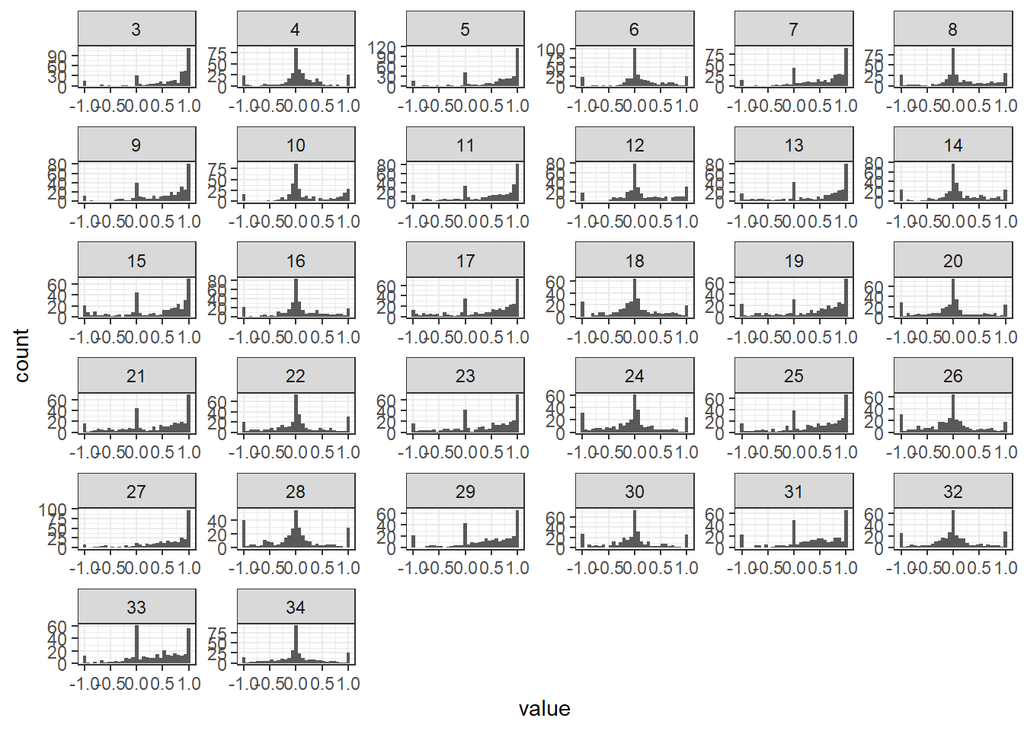

```r
my_ion %>% tibble::rowid_to_column() %>%
  tidyr::gather(key = "key", value = "value", -rowid, -Class) %>%
  mutate(input_number = as.numeric(stringr::str_extract(key, "\\d+"))) %>%
  ggplot(mapping = aes(x = value)) +
  geom_histogram(bins = 31) +
  facet_wrap(~input_number, scales = "free") +
  theme_bw()
```

Use boxplots to summarize the inputs.

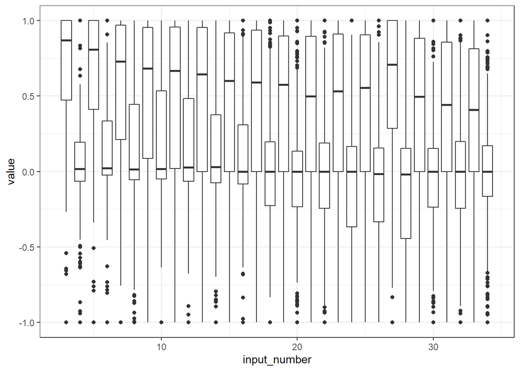

```r
my_ion %>% tibble::rowid_to_column() %>%
  tidyr::gather(key = "key", value = "value", -rowid, -Class) %>%
  mutate(input_number = as.numeric(stringr::str_extract(key, "\\d+"))) %>%
  ggplot(mapping = aes(x = input_number, y = value)) +
  geom_boxplot(mapping = aes(group = input_number)) +
  theme_bw()
```

Breakup each boxplot based on the observed output `Class`.

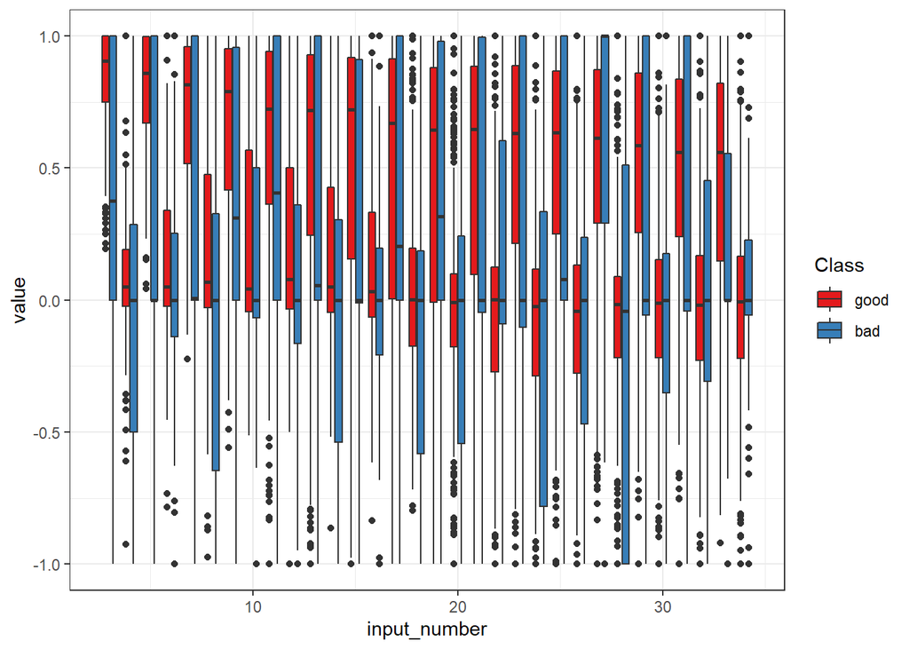

```r
my_ion %>% tibble::rowid_to_column() %>%
  tidyr::gather(key = "key", value = "value", -rowid, -Class) %>%
  mutate(input_number = as.numeric(stringr::str_extract(key, "\\d+"))) %>%
  ggplot(mapping = aes(x = input_number, y = value)) +
  geom_boxplot(mapping = aes(group = interaction(input_number, Class),
                             fill = Class)) +
  scale_fill_brewer(palette = "Set1") +
  theme_bw()
```

Check for multimodal behavior with violin plots.

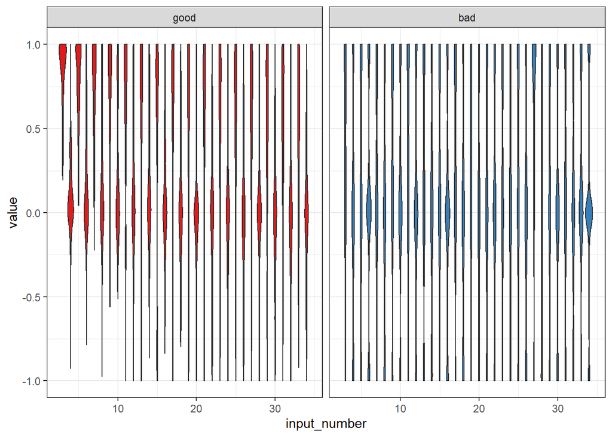

```r
my_ion %>% tibble::rowid_to_column() %>%
  tidyr::gather(key = "key", value = "value", -rowid, -Class) %>%
  mutate(input_number = as.numeric(stringr::str_extract(key, "\\d+"))) %>%
  ggplot(mapping = aes(x = input_number, y = value)) +
  geom_violin(mapping = aes(group = interaction(input_number, Class),
                            fill = Class)) +
  facet_wrap(~Class) +
  scale_fill_brewer(guide = FALSE, palette = "Set1") +
  theme_bw()
```

Check over the input correlation structure.

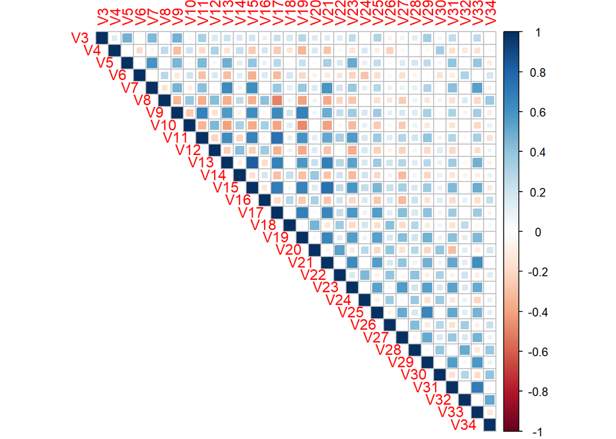

```r
my_ion %>%
  select(-Class) %>%
  cor() %>%
  corrplot::corrplot(method = "square", type = "upper")
```

Reorder the correlation matrix, using an unsupervised learning technique.

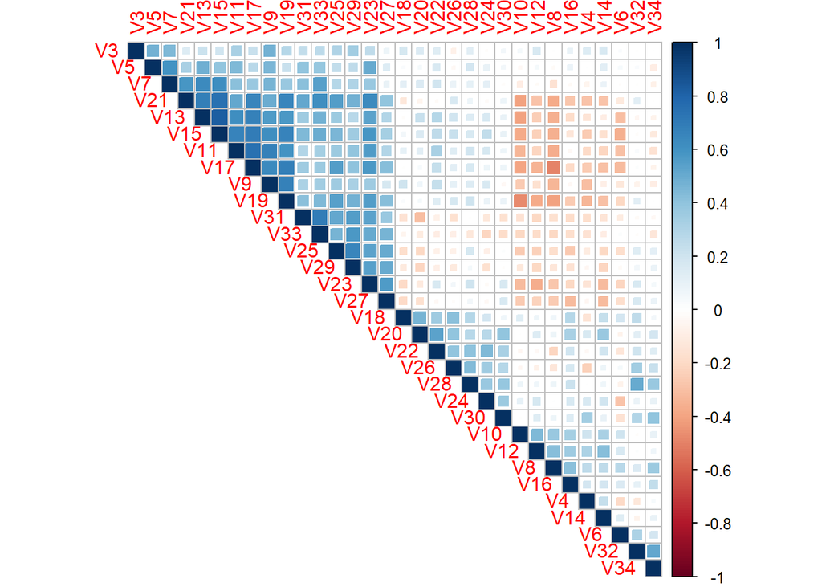

```r
my_ion %>%
  select(-Class) %>%
  cor() %>%
  corrplot::corrplot(method = "square", type = "upper", order = "hclust")
```

Look at the correlation matrix just for the `Class = "good"` observations.

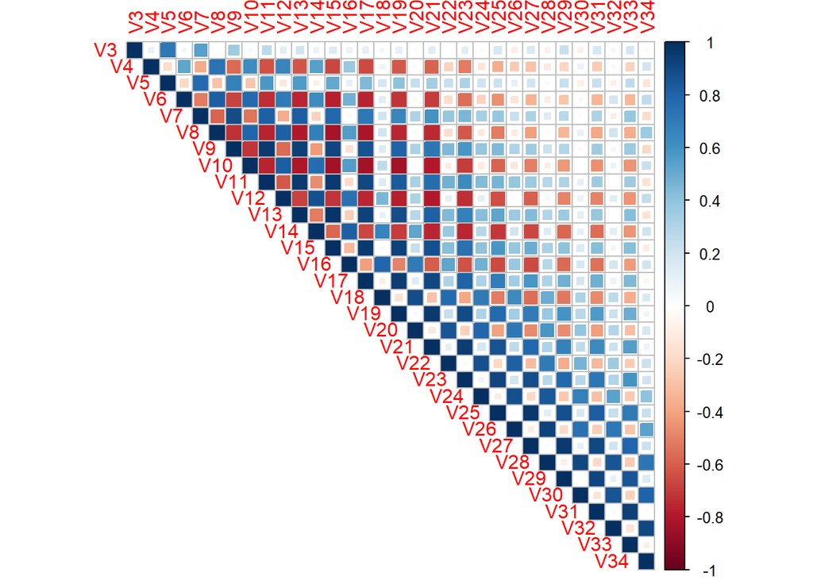

```r
my_ion %>%
  filter(Class %in% "good") %>%
  select(-Class) %>%
  cor() %>%
  corrplot::corrplot(method = "square", type = "upper")
```

Look at the correlation matrix just for the `Class = "bad"` observations.

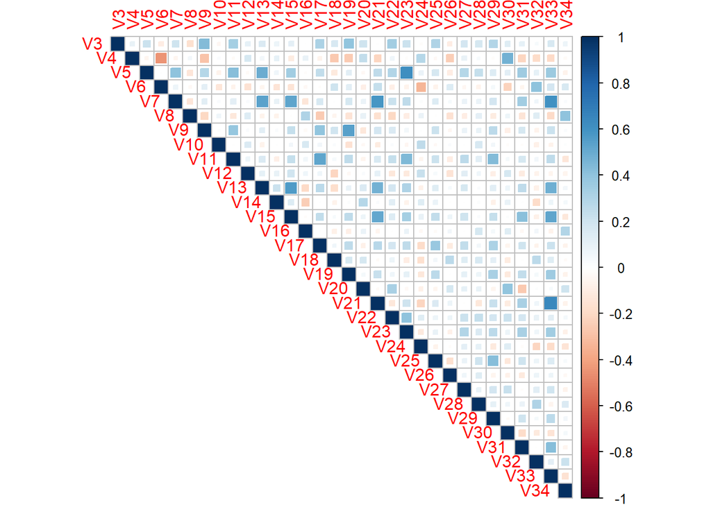

```r
my_ion %>%
  filter(Class %in% "bad") %>%
  select(-Class) %>%
  cor() %>%
  corrplot::corrplot(method = "square", type = "upper")
```

## Model training

We will try out a range of models, from simple to complex, in order to try and predict the `Class` binary outcome. We must specify the resampling scheme and metric to use with `caret`. In order to assess the models based on the Area Under the Curve (AUC), we must tell `caret` that the primary performance metric is ROC. `caret` refers to AUC as ROC. We must specify the `summaryFunction` argument to be `twoClassSummary` within the `trainControl()` function in order to maximize the area under the ROC curve.

Set the resampling control scheme to be 5-fold cross-validation with 3 repeats. We will save the predictions from the cross-validation hold-out sets in order to create ROC curves per fold. We will also instruct `caret` to return the class predicted probabilities. Specify the resampling controls in the code chunk below.

```r
ctrl <- trainControl(method = "repeatedcv", number = 5, repeats = 3,
                     summaryFunction = twoClassSummary,
                     classProbs = TRUE,
                     savePredictions = TRUE)
```

### Generalized linear methods

Start with a simple logistic regression model. We will use all inputs/features within the `my_ion` data set. The inputs themselves already appear to be normalized between -1 and +1. However, we will preprocess the inputs to study the influence of the relative change on each input compared to the others via standardization. When we wish to include all inputs, we will use the shortcut `Class ~ .` operator.

#### Logistic regression

```r
set.seed(4321)
fit_glm <- train(Class ~ ., data = my_ion,
                 method = "glm",
                 metric = "ROC",
                 preProc = c("center", "scale"),
                 trControl = ctrl)
fit_glm
```

```
## Generalized Linear Model
##
## 351 samples
##  32 predictor
##   2 classes: 'good', 'bad'
##
## Pre-processing: centered (32), scaled (32)
## Resampling: Cross-Validated (5 fold, repeated 3 times)
## Summary of sample sizes: 281, 281, 280, 281, 281, 281, ...
## Resampling results:
##
##   ROC        Sens      Spec
##   0.8465481  0.917037  0.6926154
```

Look at the confusion matrix associated with the model training.

```r
confusionMatrix.train(fit_glm)
```

```
## Cross-Validated (5 fold, repeated 3 times) Confusion Matrix
##
## (entries are percentual average cell counts across resamples)
##
##           Reference
## Prediction good  bad
##       good 58.8 11.0
##       bad   5.3 24.9
##
##  Accuracy (average) : 0.8367
```

#### Regularization

Let’s try out a regularization approach since we have a relatively high number of inputs compared with the number of observations in this example. We will use elastic net, which is a mixture between lasso and ridge penalities.

```r
set.seed(4321)
fit_glmnet <- train(Class ~ ., data = my_ion,
                    method = "glmnet",
                    metric = "ROC",
                    preProc = c("center", "scale"),
                    trControl = ctrl)

fit_glmnet
```

```
## glmnet
##
## 351 samples
##  32 predictor
##   2 classes: 'good', 'bad'
##
## Pre-processing: centered (32), scaled (32)
## Resampling: Cross-Validated (5 fold, repeated 3 times)
## Summary of sample sizes: 281, 281, 280, 281, 281, 281, ...
## Resampling results across tuning parameters:
##
##   alpha  lambda        ROC        Sens       Spec
##   0.10   0.0004980671  0.8551590  0.9274074  0.6820513
##   0.10   0.0049806710  0.8757265  0.9466667  0.6848205
##   0.10   0.0498067104  0.8954006  0.9644444  0.6848205
##   0.55   0.0004980671  0.8524422  0.9259259  0.6793846
##   0.55   0.0049806710  0.8748011  0.9496296  0.6793846
##   0.55   0.0498067104  0.8853538  0.9614815  0.6296410
##   1.00   0.0004980671  0.8481869  0.9244444  0.6793846
##   1.00   0.0049806710  0.8739943  0.9481481  0.6768205
##   1.00   0.0498067104  0.8700855  0.9570370  0.6111795
##
## ROC was used to select the optimal model using the largest value.
## The final values used for the model were alpha = 0.1 and lambda
##  = 0.04980671.
```

Let’s try out a finer grid for elastic net.

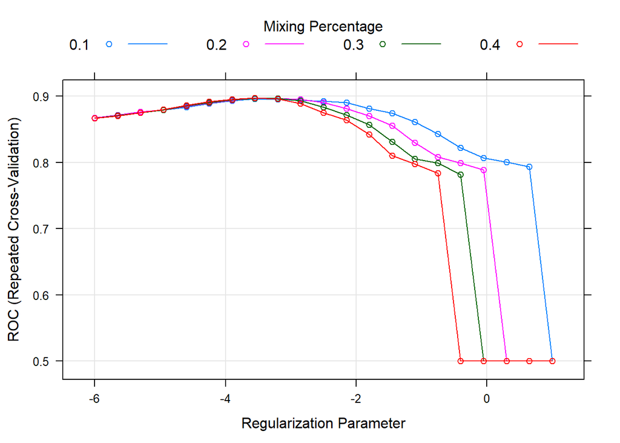

```r
enet_grid <- expand.grid(alpha = c(0.1, 0.2, 0.3, 0.4),
                         lambda = exp(seq(-6, 1, length.out = 21)))

set.seed(4321)
fit_glmnet_b <- train(Class ~ ., data = my_ion,
                      method = "glmnet",
                      metric = "ROC",
                      tuneGrid = enet_grid,
                      preProc = c("center", "scale"),
                      trControl = ctrl)

plot(fit_glmnet_b, xTrans = log)
```

Look at the tuning parameters for the best model, based on the cross-validation performance.

```r
fit_glmnet_b$bestTune
```

```
##    alpha     lambda
## 71   0.4 0.02872464
```

Check the cross-validation confusion matrix for the best model.

```r
confusionMatrix.train(fit_glmnet_b)
```

```
## Cross-Validated (5 fold, repeated 3 times) Confusion Matrix
##
## (entries are percentual average cell counts across resamples)
##
##           Reference
## Prediction good  bad
##       good 61.1 12.3
##       bad   3.0 23.6
##
##  Accuracy (average) : 0.8462
```

#### Partial Least Squares

Partial Least Squares (PLS) models are particularly well suited when the inputs are highly correlated to each other. Let’s give it a try to see how well the model performs, since we know there’s some kind of structure between the inputs.

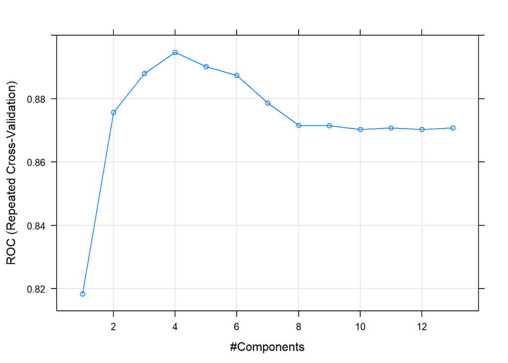

```r
pls_grid <- expand.grid(ncomp = seq(1, 13, by = 1))

set.seed(4321)
fit_pls <- train(Class ~ ., data = my_ion,
                 method = "pls",
                 metric = "ROC",
                 tuneGrid = pls_grid,
                 preProc = c("center", "scale"),
                 trControl = ctrl)

plot(fit_pls)
```

Check the confusion matrix based on repeated cross-validation.

```r
confusionMatrix.train(fit_pls)
```

```
## Cross-Validated (5 fold, repeated 3 times) Confusion Matrix
##
## (entries are percentual average cell counts across resamples)
##
##           Reference
## Prediction good  bad
##       good 61.9 12.4
##       bad   2.2 23.5
##
##  Accuracy (average) : 0.8538
```

### Non-linear methods

We will now try out several complex methods which can capture highly non-linear relationships.

#### Support vector machines

We will specifically use a Support Vector Machine (SVM) with a radial basis function (RBF) kernel. SVMs are based on the idea of dividing classes through hyperplanes. When a linear separating hyperplane does not exist, SVMs use the “kernel trick” to transform from the original space to a new feature space. Within this new transformed space, the SVM tries to create linear separating boundaris between the classes. The RBF is particularly well suited for smooth behavior. We will consider the default grid search from `caret`.

```r
set.seed(4321)
fit_svm <- train(Class ~ ., data = my_ion,
                 method = "svmRadial",
                 metric = "ROC",
                 preProc = c("center", "scale"),
                 trControl = ctrl)

fit_svm
```

```
## Support Vector Machines with Radial Basis Function Kernel
##
## 351 samples
##  32 predictor
##   2 classes: 'good', 'bad'
##
## Pre-processing: centered (32), scaled (32)
## Resampling: Cross-Validated (5 fold, repeated 3 times)
## Summary of sample sizes: 281, 281, 280, 281, 281, 281, ...
## Resampling results across tuning parameters:
##
##   C     ROC        Sens       Spec
##   0.25  0.9792729  0.9555556  0.9072821
##   0.50  0.9801048  0.9525926  0.9179487
##   1.00  0.9815772  0.9585185  0.9206154
##
## Tuning parameter 'sigma' was held constant at a value of 0.06163737
## ROC was used to select the optimal model using the largest value.
## The final values used for the model were sigma = 0.06163737 and C = 1.
```

Let’s try a refined grid search to see if the SVM with RBF can be improved further.

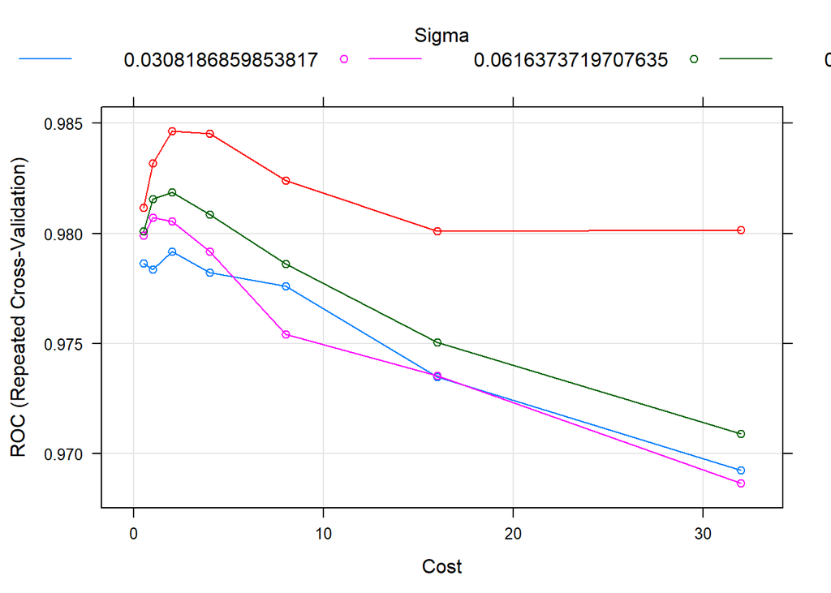

```r
rbf_grid <- expand.grid(sigma = fit_svm$bestTune$sigma * c(0.25, 0.5, 1, 2),
                        C = c(0.5, 1.0, 2.0, 4.0, 8.0, 16.0, 32.0))

set.seed(4321)
fit_svm_b <- train(Class ~ ., data = my_ion,
                   method = "svmRadial",
                   metric = "ROC",
                   tuneGrid = rbf_grid,
                   preProc = c("center", "scale"),
                   trControl = ctrl)

plot(fit_svm_b)
```

The best tuning parameter values:

```r
fit_svm_b$bestTune
```

```
##        sigma C
## 24 0.1232747 2
```

Check the cross-validation confusion matrix.

```r
confusionMatrix.train(fit_svm_b)
```

```
## Cross-Validated (5 fold, repeated 3 times) Confusion Matrix
##
## (entries are percentual average cell counts across resamples)
##
##           Reference
## Prediction good  bad
##       good 60.7  1.9
##       bad   3.4 34.0
##
##  Accuracy (average) : 0.9468
```

#### Neural networks

Start with a default tuning grid.

```r
set.seed(4321)
fit_nnet_a <- train(Class ~ ., data = my_ion,
                    method = "nnet",
                    metric = "ROC",
                    preProc = c("center", "scale"),
                    trControl = ctrl,
                    trace = FALSE)
```

```r
fit_nnet_a
```

```
## Neural Network
##
## 351 samples
##  32 predictor
##   2 classes: 'good', 'bad'
##
## Pre-processing: centered (32), scaled (32)
## Resampling: Cross-Validated (5 fold, repeated 3 times)
## Summary of sample sizes: 281, 281, 280, 281, 281, 281, ...
## Resampling results across tuning parameters:
##
##   size  decay  ROC        Sens       Spec
##   1     0e+00  0.7998439  0.9659259  0.6003077
##   1     1e-04  0.8118427  0.9555556  0.6132308
##   1     1e-01  0.7893675  0.9451852  0.6186667
##   3     0e+00  0.8789322  0.9244444  0.7480000
##   3     1e-04  0.8644877  0.9437037  0.7299487
##   3     1e-01  0.9025527  0.9674074  0.7032821
##   5     0e+00  0.8608923  0.9392593  0.7349744
##   5     1e-04  0.9010120  0.9377778  0.7427692
##   5     1e-01  0.9314689  0.9733333  0.7217436
##
## ROC was used to select the optimal model using the largest value.
## The final values used for the model were size = 5 and decay = 0.1.
```

Try increasing the number of hidden units and vary the `decay` tuning parameter more.

```r
nnet_grid <- expand.grid(size = c(3, 5, 7, 9, 11, 13, 15),
                         decay = c(0.1, 0.25, 0.5, 0.75))

set.seed(4321)
fit_nnet_b <- train(Class ~ ., data = my_ion,
                    method = "nnet",
                    metric = "ROC",
                    tuneGrid = nnet_grid,
                    preProc = c("center", "scale"),
                    trControl = ctrl,
                    trace = FALSE)
```

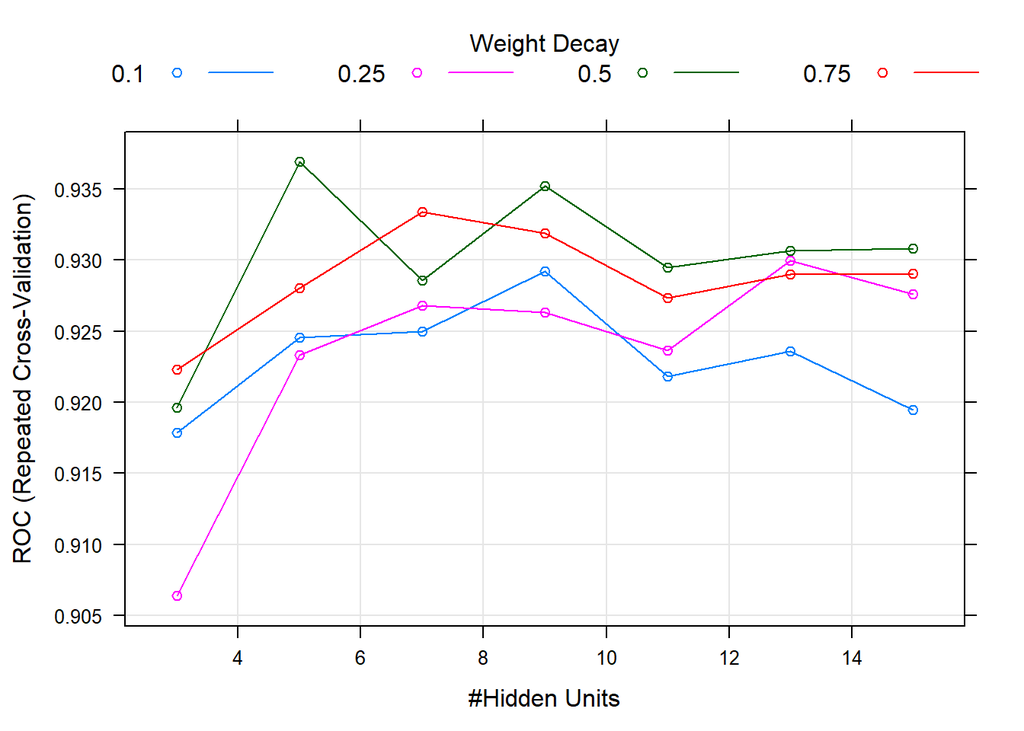

```r
plot(fit_nnet_b)
```

Check the confusion matrix based on the cross-validation results.

```r
confusionMatrix.train(fit_nnet_b)
```

```
## Cross-Validated (5 fold, repeated 3 times) Confusion Matrix
##
## (entries are percentual average cell counts across resamples)
##
##           Reference
## Prediction good  bad
##       good 62.3 11.3
##       bad   1.8 24.6
##
##  Accuracy (average) : 0.8689
```

#### Random forest

The random forest model creates 500 bagged tree models. Compared to a standard bagged tree model, the random forest randomly selects the number of features to consider during the splitting process.

```r
rf_grid <- expand.grid(mtry = c(2, 3, 6, 9, 12, 15))

set.seed(4321)
fit_rf <- train(Class ~ ., data = my_ion,
                method = "rf",
                metric = "ROC",
                trControl = ctrl,
                tuneGrid = rf_grid,
                importance = TRUE)

fit_rf
```

```
## Random Forest
##
## 351 samples
##  32 predictor
##   2 classes: 'good', 'bad'
##
## No pre-processing
## Resampling: Cross-Validated (5 fold, repeated 3 times)
## Summary of sample sizes: 281, 281, 280, 281, 281, 281, ...
## Resampling results across tuning parameters:
##
##   mtry  ROC        Sens       Spec
##    2    0.9798735  0.9600000  0.8727179
##    3    0.9799909  0.9629630  0.8753846
##    6    0.9797687  0.9644444  0.8807179
##    9    0.9764957  0.9688889  0.8780513
##   12    0.9760581  0.9644444  0.8727179
##   15    0.9752957  0.9659259  0.8727179
##
## ROC was used to select the optimal model using the largest value.
## The final value used for the model was mtry = 3.
```

Check the confusion matrix.

```r
confusionMatrix.train(fit_rf)
```

```
## Cross-Validated (5 fold, repeated 3 times) Confusion Matrix
##
## (entries are percentual average cell counts across resamples)
##
##           Reference
## Prediction good  bad
##       good 61.7  4.5
##       bad   2.4 31.4
##
##  Accuracy (average) : 0.9316
```

## Model Comparison

Assemble the resampled results together.

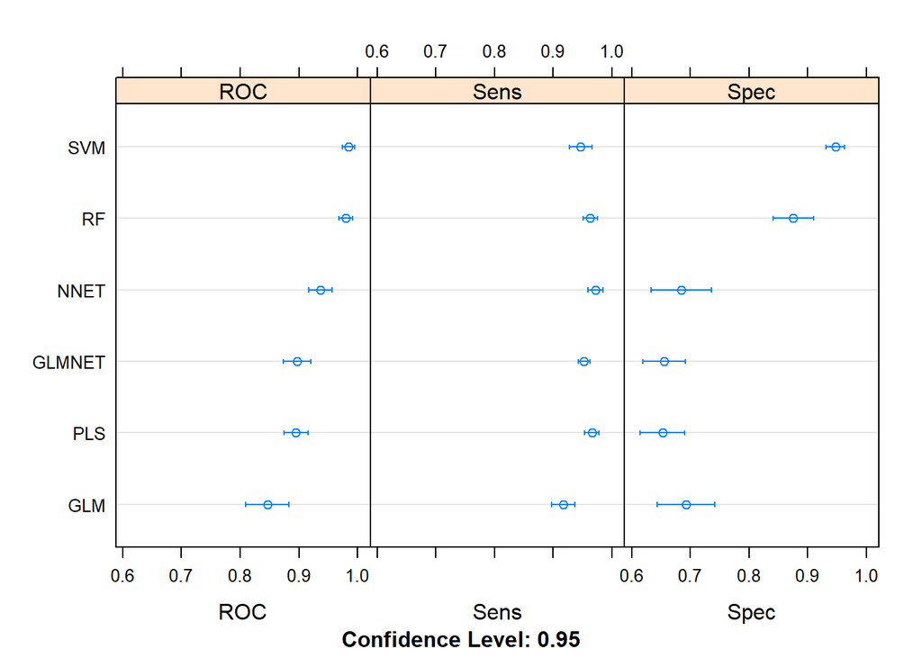

```r
model_cv_res <- resamples(list(GLM = fit_glm,
                               GLMNET = fit_glmnet_b,
                               PLS = fit_pls,
                               SVM = fit_svm_b,
                               NNET = fit_nnet_b,
                               RF = fit_rf))

dotplot(model_cv_res)
```

Based on the Area under the ROC curve (AUC), as ROC as stated by `caret`, the SVM and random forest are rather similar to each other. The model with the highest Sensitivity is a little surpising they all perform on the same magnitude. Specificity has a clear difference between models.

Now, let’s assumble the ROC curves for comparison. First, we need to identify the best tuned model and combine the cross-validation hold-out set predictions together.

```r
cv_pred_results <- fit_glm$pred %>% tbl_df() %>%
  filter(parameter == fit_glm$bestTune$parameter) %>%
  select(pred, obs, good, bad, rowIndex, Resample) %>%
  mutate(model_name = "GLM") %>%
  bind_rows(fit_glmnet_b$pred %>% tbl_df() %>%
              filter(alpha %in% fit_glmnet_b$bestTune$alpha,
                     lambda %in% fit_glmnet_b$bestTune$lambda) %>%
              select(pred, obs, good, bad, rowIndex, Resample) %>%
              mutate(model_name = "GLMNET")) %>%
  bind_rows(fit_pls$pred %>% tbl_df() %>%
              filter(ncomp %in% fit_pls$bestTune$ncomp) %>%
              select(pred, obs, good, bad, rowIndex, Resample) %>%
              mutate(model_name = "PLS")) %>%
  bind_rows(fit_svm_b$pred %>% tbl_df() %>%
              filter(sigma %in% fit_svm_b$bestTune$sigma,
                     C %in% fit_svm_b$bestTune$C) %>%
              select(pred, obs, good, bad, rowIndex, Resample) %>%
              mutate(model_name = "SVM")) %>%
  bind_rows(fit_nnet_b$pred %>% tbl_df() %>%
              filter(size == fit_nnet_b$bestTune$size,
                     decay == fit_nnet_b$bestTune$decay) %>%
              select(pred, obs, good, bad, rowIndex, Resample) %>%
              mutate(model_name = "NNET")) %>%
  bind_rows(fit_rf$pred %>% tbl_df() %>%
              filter(mtry == fit_rf$bestTune$mtry) %>%
              select(pred, obs, good, bad, rowIndex, Resample) %>%
              mutate(model_name = "RF"))
```

Use the `plotROC` package to create the ROC curves.

```r
library(plotROC)
```

Visualize the ROC curves for each fold-resample broken up by the methods. The behavior across folds gives a clue about the uncertainty of the method.

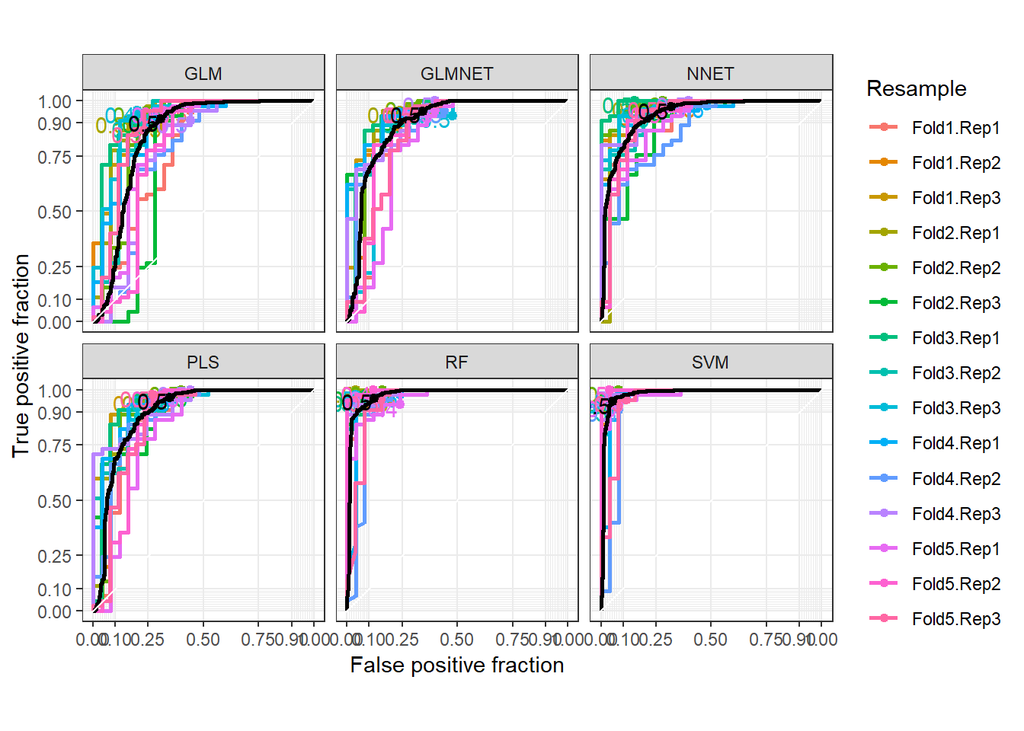

```r
cv_pred_results %>%
  ggplot(mapping = aes(m = good,
                       d = ifelse(obs == "good",
                                  1,
                                  0))) +
  geom_roc(cutoffs.at = 0.5,
           mapping = aes(color = Resample)) +
  geom_roc(cutoffs.at = 0.5) +
  coord_equal() +
  facet_wrap(~model_name) +
  style_roc()
```

Examine the neural network results more closely. The black line is the ROC curve averaged over all folds and repeats. The model seems to be perform considerably well on a few folds, but suffers on a few folds.

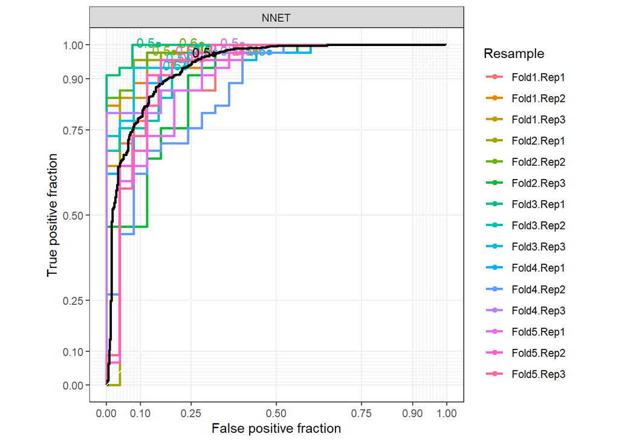

```r
cv_pred_results %>%
  filter(model_name == "NNET") %>%
  ggplot(mapping = aes(m = good,
                       d = ifelse(obs == "good",
                                  1,
                                  0))) +
  geom_roc(cutoffs.at = 0.5,
           mapping = aes(color = Resample)) +
  geom_roc(cutoffs.at = 0.5) +
  coord_equal() +
  facet_wrap(~model_name) +
  style_roc()
```

The SVM model has much tighter performance across all of the folds and repeats.

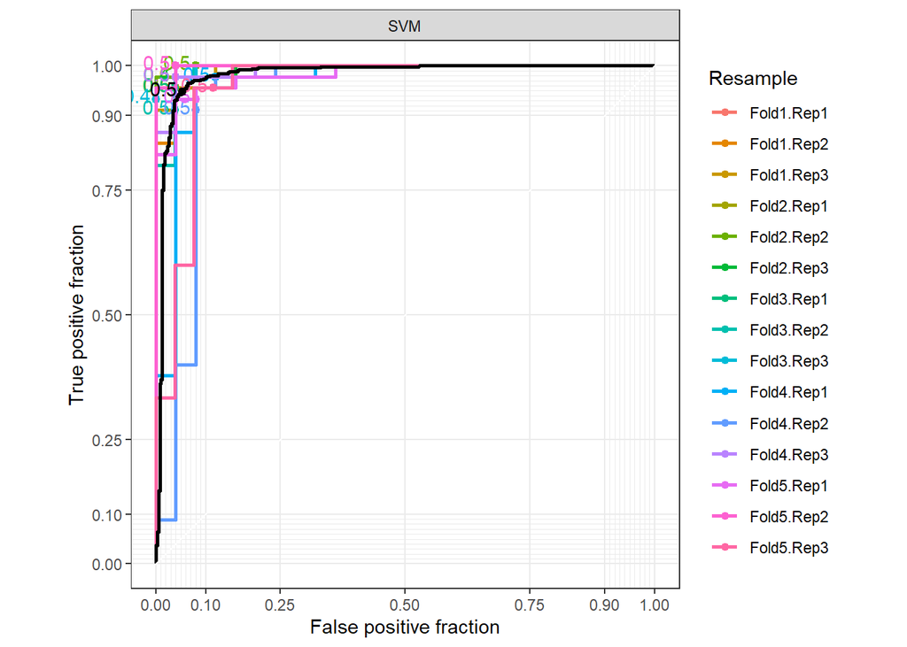

```r
cv_pred_results %>%
  filter(model_name == "SVM") %>%
  ggplot(mapping = aes(m = good,
                       d = ifelse(obs == "good",
                                  1,
                                  0))) +
  geom_roc(cutoffs.at = 0.5,
           mapping = aes(color = Resample)) +
  geom_roc(cutoffs.at = 0.5) +
  coord_equal() +
  facet_wrap(~model_name) +
  style_roc()
```

Let’s directly compare the cross-validation averaged ROC curves across the 6 different models.

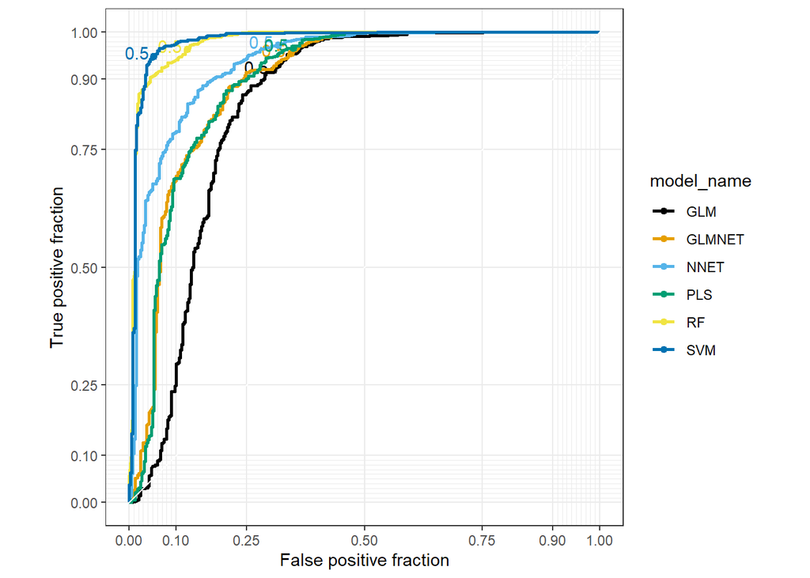

```r
cv_pred_results %>%
  ggplot(mapping = aes(m = good,
                       d = ifelse(obs == "good",
                                  1,
                                  0),
                       color = model_name)) +
  geom_roc(cutoffs.at = 0.5) +
  coord_equal() +
  style_roc() +
  ggthemes::scale_color_colorblind()
```

Let’s also consider the calibration curves associated with the cross-validation hold-out sets for a few of the models. We need to reorganize the fold hold-out results before we can use the build in functions which generate the calibration curves. We will consider the elastic net, the SVM, and the neural network models.

```r
glmnet_test_pred_good <- fit_glmnet_b$pred %>% tbl_df() %>%
              filter(alpha %in% fit_glmnet_b$bestTune$alpha,
                     lambda %in% fit_glmnet_b$bestTune$lambda) %>%
              select(obs, good, rowIndex, Resample)

svm_test_pred_good <- fit_svm_b$pred %>% tbl_df() %>%
              filter(sigma %in% fit_svm_b$bestTune$sigma,
                     C %in% fit_svm_b$bestTune$C) %>%
              select(obs, good, rowIndex, Resample)

nnet_test_pred_good <- fit_nnet_b$pred %>% tbl_df() %>%
              filter(size == fit_nnet_b$bestTune$size,
                     decay == fit_nnet_b$bestTune$decay) %>%
              select(obs, good, rowIndex, Resample)
```

```r
cal_holdout_preds <- glmnet_test_pred_good %>% rename(GLMNET = good) %>%
  left_join(svm_test_pred_good %>% rename(SVM = good),
            by = c("obs", "rowIndex", "Resample")) %>%
  left_join(nnet_test_pred_good %>% rename(NNET = good),
            by = c("obs", "rowIndex", "Resample")) %>%
  select(Class = obs, GLMNET, NNET, SVM)
```

And now we can generate the calibration curves for the three models we wish to compare. As shown below, the neural network model over predicts the emprical frequency within each bin, while the SVM under predicts the frequency.

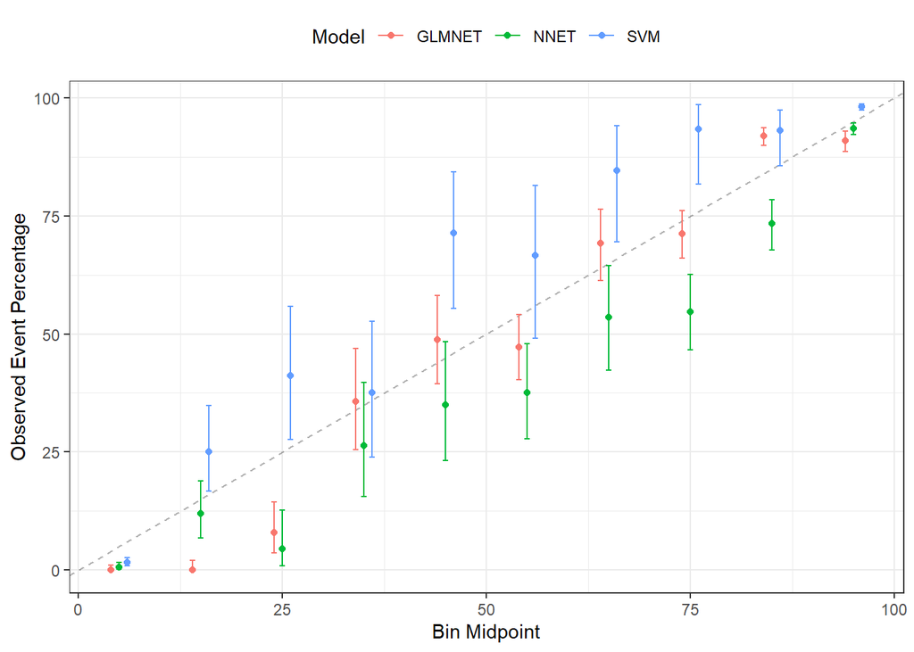

```r
cal_object <- calibration(Class ~ GLMNET + NNET + SVM,
                          data = cal_holdout_preds,
                          cuts = 10)

ggplot(cal_object) + theme_bw() + theme(legend.position = "top")
```

Let’s retry with fewer bins. The results appear consistent with calibration curve based on 10 bins, instead of 5. The simpler linear elastic net model appears to be well calibrated, except for he lowest prediceted probability values. However, we already saw that point-wise predictive accuracy metrics were lower for the elastic net model. It’s important to consider multiple performance metrics in order to get a sense how the model will perform on a point-by-point basis, as well as in the long run.

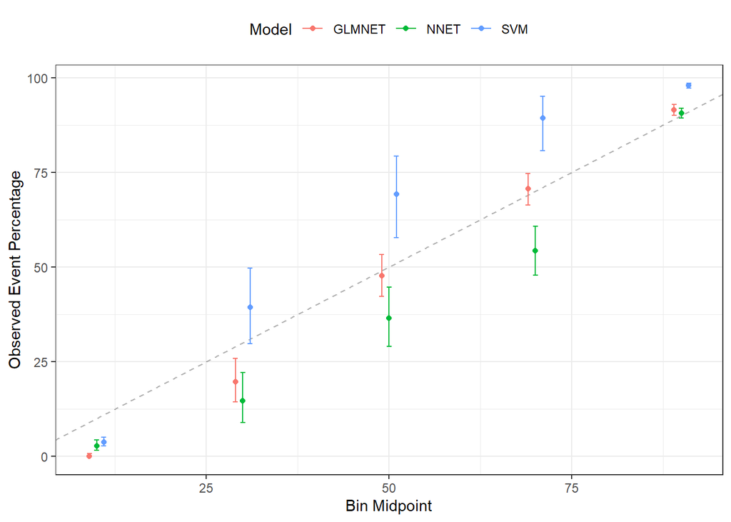

```r
cal_object <- calibration(Class ~ GLMNET + NNET + SVM,
                          data = cal_holdout_preds,
                          cuts = 5)

ggplot(cal_object) + theme_bw() + theme(legend.position = "top")
```